# Vaja 2 - Morfoloske operacije nad multispektralnimi indeksi

V tem notebooku uporabim rezultate iz Vaje 1 in rocno implementiram morfoloske operacije.

## Pregled

V nadaljevanju so prikazani vhodni podatki iz Vaje 1, izbrani izrezi ter rezultati morfoloskih operacij za tri razlicne tipe povrsin.

## Okolje

Uporabljene so knjiznice numpy, rasterio, matplotlib in pandas.

```python
from dataclasses import dataclass
from pathlib import Path
import time

import matplotlib.pyplot as plt
import numpy as np
import pandas as pd
import rasterio
from IPython.display import Image, Markdown, display
from rasterio.windows import Window, transform as window_transform

PROJECT_ROOT = Path.cwd().resolve().parent if Path.cwd().name == 'notebooks' else Path.cwd().resolve()
OUTPUT_PNG_DIR = PROJECT_ROOT / 'outputs' / 'png'
OUTPUT_TIF_DIR = PROJECT_ROOT / 'outputs' / 'tif'
OUTPUT_CROPS_DIR = PROJECT_ROOT / 'outputs' / 'crops'
OUTPUT_TABLES_DIR = PROJECT_ROOT / 'outputs' / 'tables'
NODATA_VALUE = -9999.0
BASE_RADIUS = 3
RECON_RADIUS = 1
CROP_SIZE = 512
CMAPS = {
    'ndvi': 'YlGn',
    'ndwi': 'Blues',
    'ndbi': 'copper',
}

for directory in [OUTPUT_PNG_DIR, OUTPUT_TIF_DIR, OUTPUT_CROPS_DIR, OUTPUT_TABLES_DIR]:
    directory.mkdir(parents=True, exist_ok=True)


def resolve_vaja1_root(project_root: Path) -> Path:
    candidates = [
        project_root.parent / 'Vaja 1',
        project_root / 'Vaja 1',
    ]
    for candidate in candidates:
        if (candidate / 'outputs' / 'tif').exists():
            return candidate
    raise FileNotFoundError('Ne najdem mape Vaja 1 z outputs/tif.')


VAJA1_ROOT = resolve_vaja1_root(PROJECT_ROOT)

print('Project root:', PROJECT_ROOT)
print('Vaja 1 root:', VAJA1_ROOT)
print('PNG output dir:', OUTPUT_PNG_DIR)
print('TIF output dir:', OUTPUT_TIF_DIR)
print('Tables output dir:', OUTPUT_TABLES_DIR)
```

```
Project root: /Users/nemanjamitric/Projects/FERI/Semester 3/AOPDZ/Vaja 2
Vaja 1 root: /Users/nemanjamitric/Projects/FERI/Semester 3/AOPDZ/Vaja 1
PNG output dir: /Users/nemanjamitric/Projects/FERI/Semester 3/AOPDZ/Vaja 2/outputs/png
TIF output dir: /Users/nemanjamitric/Projects/FERI/Semester 3/AOPDZ/Vaja 2/outputs/tif
Tables output dir: /Users/nemanjamitric/Projects/FERI/Semester 3/AOPDZ/Vaja 2/outputs/tables
```

## Vhodni podatki iz Vaje 1

Vhodne slike so ze izracunani multispektralni indeksi iz prve vaje. Tako ni treba ponovno racunati pasov Sentinel-2, ampak neposredno obdelam sivinske rastrske slike indeksov.

```python
INDEX_TIF_DIR = VAJA1_ROOT / 'outputs' / 'tif'
AVAILABLE_INDEX_FILES = {path.stem.lower(): path for path in sorted(INDEX_TIF_DIR.glob('*.tif'))}

if not AVAILABLE_INDEX_FILES:
    raise FileNotFoundError('V Vaji 1 ni bilo najdenih .tif datotek.')

pd.DataFrame(
    [
        {
            'Index': key,
            'Path': str(path),
        }
        for key, path in AVAILABLE_INDEX_FILES.items()
    ]
)
```

|  | Index | Path |
| --- | --- | --- |
| 0 | evi | /Users/nemanjamitric/Projects/FERI/Semester 3/... |
| 1 | gndvi | /Users/nemanjamitric/Projects/FERI/Semester 3/... |
| 2 | mndwi | /Users/nemanjamitric/Projects/FERI/Semester 3/... |
| 3 | msi | /Users/nemanjamitric/Projects/FERI/Semester 3/... |
| 4 | nbr | /Users/nemanjamitric/Projects/FERI/Semester 3/... |
| 5 | ndbi | /Users/nemanjamitric/Projects/FERI/Semester 3/... |
| 6 | ndmi | /Users/nemanjamitric/Projects/FERI/Semester 3/... |
| 7 | ndre | /Users/nemanjamitric/Projects/FERI/Semester 3/... |
| 8 | ndvi | /Users/nemanjamitric/Projects/FERI/Semester 3/... |
| 9 | ndwi | /Users/nemanjamitric/Projects/FERI/Semester 3/... |
| 10 | savi | /Users/nemanjamitric/Projects/FERI/Semester 3/... |
| 11 | vari | /Users/nemanjamitric/Projects/FERI/Semester 3/... |

## Izbrane lokacije in indeksi

Za porocilo uporabim tri razlicna podrocja, da zajamem tri razlicne tipe povrsin:

- river_corridor: podrocje z izrazito vodno oziroma linearno strukturo
- field_mosaic: kmetijska mreza z veliko lokalnimi spremembami
- builtup_patch: obmocje z vec pozidanimi in mesanimi povrsinami

Vsaka lokacija uporablja izbran indeks iz Vaje 1. Recni izrez je velikosti 512 x 512, preostala dva izreza pa 1024 x 1024.

|  | Area | Index | Title | X | Y | Base radius | Size |
| --- | --- | --- | --- | --- | --- | --- | --- |
| 0 | river_corridor | ndwi | Recni koridor na NDWI | 3700 | 5000 | 4 | 512 |
| 1 | field_mosaic | ndvi | Poljska mreza na NDVI | 900 | 1000 | 2 | 1024 |
| 2 | builtup_patch | ndbi | Pozidano obmocje na NDBI | 9300 | 100 | 2 | 1024 |

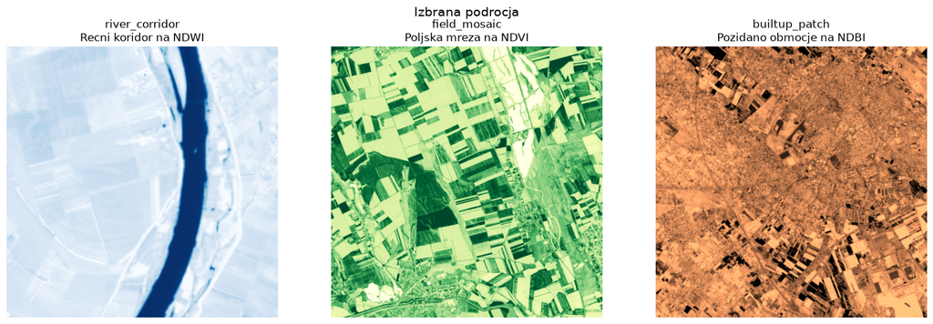

```python
@dataclass(frozen=True)
class ExperimentSpec:
    area_code: str
    index_code: str
    title: str
    x: int
    y: int
    base_radius: int = BASE_RADIUS
    size: int = CROP_SIZE


EXPERIMENTS = [
    ExperimentSpec('river_corridor', 'ndwi', 'Recni koridor na NDWI', 3700, 5000, base_radius=4),
    ExperimentSpec('field_mosaic', 'ndvi', 'Poljska mreza na NDVI', 900, 1000, base_radius=2, size=1024),
    ExperimentSpec('builtup_patch', 'ndbi', 'Pozidano obmocje na NDBI', 9300, 100, base_radius=2, size=1024),
]

missing_indices = sorted({experiment.index_code for experiment in EXPERIMENTS} - set(AVAILABLE_INDEX_FILES))
if missing_indices:
    raise FileNotFoundError('Manjkajoci indeksi: ' + ', '.join(missing_indices))

experiments_df = pd.DataFrame([
    {
        'Area': experiment.area_code,
        'Index': experiment.index_code,
        'Title': experiment.title,
        'X': experiment.x,
        'Y': experiment.y,
        'Base radius': experiment.base_radius,
        'Size': experiment.size,
    }
    for experiment in EXPERIMENTS
])
display(experiments_df)

fig, axes = plt.subplots(1, 3, figsize=(15, 5))
for ax, experiment in zip(axes, EXPERIMENTS):
    with rasterio.open(AVAILABLE_INDEX_FILES[experiment.index_code]) as src:
        window = Window(experiment.x, experiment.y, experiment.size, experiment.size)
        preview = src.read(1, window=window, masked=True).astype('float32')

    preview_array = np.asarray(preview, dtype='float32')
    valid = preview_array[np.isfinite(preview_array)]
    if valid.size:
        vmin = float(np.nanpercentile(valid, 2))
        vmax = float(np.nanpercentile(valid, 98))
        if np.isclose(vmin, vmax):
            vmin = float(valid.min())
            vmax = float(valid.max())
    else:
        vmin, vmax = 0.0, 1.0

    ax.imshow(preview_array, cmap=CMAPS[experiment.index_code], vmin=vmin, vmax=vmax)
    ax.set_title(f'{experiment.area_code}\n{experiment.title}')
    ax.axis('off')

fig.suptitle('Izbrana podrocja', fontsize=14)
fig.tight_layout()
```

## Osnovne morfoloske operacije

Najprej implementiram osnovni operaciji krcenje in sirjenje. Uporabim svoje premike znotraj strukturnega elementa.

Pravilo na robovih slike je preprosto: okno porezem na veljavne piksle znotraj slike. Ni nicelnega dopolnjevanja in ni zrcaljenja.

```python
def build_offsets(shape_name: str, radius: int) -> list[tuple[int, int]]:
    offsets = []
    for dy in range(-radius, radius + 1):
        for dx in range(-radius, radius + 1):
            include = False
            if shape_name == 'square':
                include = True
            elif shape_name == 'cross':
                include = dx == 0 or dy == 0
            elif shape_name == 'disk':
                include = dx * dx + dy * dy <= radius * radius
            else:
                raise ValueError(f'Nepodprta oblika filtra: {shape_name}')
            if include:
                offsets.append((dy, dx))
    if not offsets:
        raise ValueError('Seznam premikov ne sme biti prazen.')
    return offsets


def apply_extreme_filter(image: np.ndarray, offsets: list[tuple[int, int]], mode: str) -> np.ndarray:
    image = np.asarray(image, dtype='float32')
    height, width = image.shape
    if mode == 'min':
        result = np.full((height, width), np.inf, dtype='float32')
    elif mode == 'max':
        result = np.full((height, width), -np.inf, dtype='float32')
    else:
        raise ValueError('Mode mora biti min ali max.')

    for dy, dx in offsets:
        if dy >= 0:
            src_y0, src_y1 = 0, height - dy
            dst_y0, dst_y1 = dy, height
        else:
            src_y0, src_y1 = -dy, height
            dst_y0, dst_y1 = 0, height + dy

        if dx >= 0:
            src_x0, src_x1 = 0, width - dx
            dst_x0, dst_x1 = dx, width
        else:
            src_x0, src_x1 = -dx, width
            dst_x0, dst_x1 = 0, width + dx

        source_view = image[src_y0:src_y1, src_x0:src_x1]
        target_view = result[dst_y0:dst_y1, dst_x0:dst_x1]

        if mode == 'min':
            np.minimum(target_view, source_view, out=target_view)
        else:
            np.maximum(target_view, source_view, out=target_view)

    return result


def apply_erosion(image: np.ndarray, offsets: list[tuple[int, int]]) -> np.ndarray:
    return apply_extreme_filter(image, offsets, mode='min')


def apply_dilation(image: np.ndarray, offsets: list[tuple[int, int]]) -> np.ndarray:
    return apply_extreme_filter(image, offsets, mode='max')


def apply_opening(image: np.ndarray, offsets: list[tuple[int, int]]) -> np.ndarray:
    return apply_dilation(apply_erosion(image, offsets), offsets)


def apply_closing(image: np.ndarray, offsets: list[tuple[int, int]]) -> np.ndarray:
    return apply_erosion(apply_dilation(image, offsets), offsets)
```

## Odpiranje, zapiranje in rekonstrukcija

Rekonstrukcija poteka iterativno. Najprej dobim oznacevalno sliko s klasicnim filtrom velikosti S > 1, potem pa izvajam rekonstrukcijsko sirjenje oziroma krcenje z S = 1 toliko casa, da sta dve zaporedni sliki enaki.

```python
def reconstruct_by_dilation(marker: np.ndarray, mask: np.ndarray, offsets_s1: list[tuple[int, int]]) -> tuple[np.ndarray, int]:
    current = np.asarray(marker, dtype='float32').copy()
    mask = np.asarray(mask, dtype='float32')
    iterations = 0
    while True:
        next_image = apply_dilation(current, offsets_s1)
        np.minimum(next_image, mask, out=next_image)
        iterations += 1
        if np.array_equal(next_image, current):
            return next_image, iterations
        current = next_image


def reconstruct_by_erosion(marker: np.ndarray, mask: np.ndarray, offsets_s1: list[tuple[int, int]]) -> tuple[np.ndarray, int]:
    current = np.asarray(marker, dtype='float32').copy()
    mask = np.asarray(mask, dtype='float32')
    iterations = 0
    while True:
        next_image = apply_erosion(current, offsets_s1)
        np.maximum(next_image, mask, out=next_image)
        iterations += 1
        if np.array_equal(next_image, current):
            return next_image, iterations
        current = next_image


def apply_opening_by_reconstruction(image: np.ndarray, offsets_main: list[tuple[int, int]], offsets_s1: list[tuple[int, int]]) -> tuple[np.ndarray, int]:
    marker = apply_erosion(image, offsets_main)
    return reconstruct_by_dilation(marker, image, offsets_s1)


def apply_closing_by_reconstruction(image: np.ndarray, offsets_main: list[tuple[int, int]], offsets_s1: list[tuple[int, int]]) -> tuple[np.ndarray, int]:
    marker = apply_dilation(image, offsets_main)
    return reconstruct_by_erosion(marker, image, offsets_s1)
```

## Bonus filtri

Za bonus uporabim tri oblike filtrov. Glavni del naloge uporablja kvadratni filter, dodatno pa primerjam se cross in disk.

```python
SHAPE_NAMES = ['square', 'cross', 'disk']
OFFSET_SUMMARY_DF = pd.DataFrame([
    {
        'Shape': shape_name,
        'Pixels at S=2': len(build_offsets(shape_name, BASE_RADIUS)),
        'Pixels at S=1': len(build_offsets(shape_name, RECON_RADIUS)),
    }
    for shape_name in SHAPE_NAMES
])
OFFSET_SUMMARY_DF
```

|  | Shape | Pixels at S=2 | Pixels at S=1 |
| --- | --- | --- | --- |
| 0 | square | 49 | 9 |
| 1 | cross | 13 | 5 |
| 2 | disk | 29 | 5 |

## Priprava izrezov

V tem koraku preberem tri izbrane izreze in shranim vhodne slike.

```python
def compute_display_range(array: np.ndarray) -> tuple[float, float]:
    values = np.asarray(array, dtype='float32')
    valid = values[np.isfinite(values)]
    if valid.size == 0:
        return 0.0, 1.0
    vmin = float(np.nanpercentile(valid, 2))
    vmax = float(np.nanpercentile(valid, 98))
    if np.isclose(vmin, vmax):
        vmin = float(valid.min())
        vmax = float(valid.max())
    return vmin, vmax


def save_preview_image(array: np.ndarray, output_path: Path, title: str, cmap: str) -> Path:
    output_path.parent.mkdir(parents=True, exist_ok=True)
    vmin, vmax = compute_display_range(array)
    fig, ax = plt.subplots(figsize=(6, 6))
    image = ax.imshow(array, cmap=cmap, vmin=vmin, vmax=vmax)
    ax.set_title(title)
    ax.axis('off')
    fig.colorbar(image, ax=ax, fraction=0.046, pad=0.04)
    fig.tight_layout()
    fig.savefig(output_path, dpi=180, bbox_inches='tight')
    plt.close(fig)
    return output_path


def save_array_tif(array: np.ndarray, output_path: Path, profile: dict) -> Path:
    output_path.parent.mkdir(parents=True, exist_ok=True)
    profile = profile.copy()
    profile.update(driver='GTiff', dtype='float32', count=1, compress='deflate', predictor=3)
    with rasterio.open(output_path, 'w', **profile) as dst:
        dst.write(np.asarray(array, dtype='float32'), 1)
    return output_path


def load_crop(experiment: ExperimentSpec) -> tuple[np.ndarray, dict, Path]:
    index_path = AVAILABLE_INDEX_FILES[experiment.index_code]
    with rasterio.open(index_path) as src:
        if experiment.x < 0 or experiment.y < 0:
            raise ValueError(f'Negativne koordinate pri {experiment.area_code}.')
        if experiment.x + experiment.size > src.width or experiment.y + experiment.size > src.height:
            raise ValueError(f'Izrez {experiment.area_code} gre izven meje slike.')

        window = Window(experiment.x, experiment.y, experiment.size, experiment.size)
        crop = src.read(1, window=window, masked=True).astype('float32')
        if np.ma.getmaskarray(crop).any():
            raise ValueError(f'Izrez {experiment.area_code} vsebuje maskirane vrednosti.')

        array = np.asarray(crop, dtype='float32')
        profile = src.profile.copy()
        profile.update(
            width=experiment.size,
            height=experiment.size,
            transform=window_transform(window, src.transform),
            dtype='float32',
            count=1,
            nodata=src.nodata if src.nodata is not None else NODATA_VALUE,
        )
    return array, profile, index_path


PREPARED_INPUTS = {}
for experiment in EXPERIMENTS:
    crop_array, crop_profile, index_path = load_crop(experiment)
    crop_png_path = OUTPUT_CROPS_DIR / f'{experiment.area_code}_{experiment.index_code}_input.png'
    save_preview_image(crop_array, crop_png_path, f'{experiment.title} - vhod', CMAPS[experiment.index_code])
    PREPARED_INPUTS[experiment.area_code] = {
        'experiment': experiment,
        'array': crop_array,
        'profile': crop_profile,
        'index_path': index_path,
        'input_png': crop_png_path,
    }

pd.DataFrame([
    {
        'Area': item['experiment'].area_code,
        'Index': item['experiment'].index_code,
        'Input PNG': str(item['input_png']),
    }
    for item in PREPARED_INPUTS.values()
])
```

|  | Area | Index | Input PNG |
| --- | --- | --- | --- |
| 0 | river_corridor | ndwi | /Users/nemanjamitric/Projects/FERI/Semester 3/... |
| 1 | field_mosaic | ndvi | /Users/nemanjamitric/Projects/FERI/Semester 3/... |
| 2 | builtup_patch | ndbi | /Users/nemanjamitric/Projects/FERI/Semester 3/... |

## Izracun rezultatov

Za vsako lokacijo izracunam odpiranje, zapiranje, odpiranje z rekonstrukcijo in zapiranje z rekonstrukcijo. Pri bonus primerjavi so uporabljene tri oblike filtrov.

```python
def run_sanity_checks() -> None:
    square_main = build_offsets('square', 2)
    square_recon = build_offsets('square', RECON_RADIUS)

    constant = np.full((7, 7), 5.0, dtype='float32')
    assert np.array_equal(apply_erosion(constant, square_main), constant)
    assert np.array_equal(apply_dilation(constant, square_main), constant)
    assert np.array_equal(apply_opening(constant, square_main), constant)
    assert np.array_equal(apply_closing(constant, square_main), constant)

    toy = np.array([
        [0, 0, 0, 0, 0],
        [0, 1, 5, 1, 0],
        [0, 2, 9, 2, 0],
        [0, 1, 5, 1, 0],
        [0, 0, 0, 0, 0],
    ], dtype='float32')

    toy_open_rec, toy_open_iterations = apply_opening_by_reconstruction(toy, square_main, square_recon)
    toy_close_rec, toy_close_iterations = apply_closing_by_reconstruction(toy, square_main, square_recon)
    assert toy_open_rec.shape == toy.shape
    assert toy_close_rec.shape == toy.shape
    assert toy_open_iterations > 0
    assert toy_close_iterations > 0


run_sanity_checks()

RESULTS_BY_AREA = {}
METRIC_ROWS = []

for area_code, item in PREPARED_INPUTS.items():
    experiment = item['experiment']
    image = item['array']
    profile = item['profile']
    cmap = CMAPS[experiment.index_code]
    output_base = f'{experiment.area_code}_{experiment.index_code}'

    square_main_offsets = build_offsets('square', experiment.base_radius)
    square_recon_offsets = build_offsets('square', RECON_RADIUS)

    opening = apply_opening(image, square_main_offsets)
    closing = apply_closing(image, square_main_offsets)
    opening_rec_square, opening_rec_square_iterations = apply_opening_by_reconstruction(image, square_main_offsets, square_recon_offsets)
    closing_rec_square, closing_rec_square_iterations = apply_closing_by_reconstruction(image, square_main_offsets, square_recon_offsets)

    assert opening.shape == image.shape
    assert closing.shape == image.shape
    assert opening_rec_square.shape == image.shape
    assert closing_rec_square.shape == image.shape

    opening_png = save_preview_image(opening, OUTPUT_PNG_DIR / f'{output_base}_opening_square.png', f'{experiment.title} - odpiranje', cmap)
    closing_png = save_preview_image(closing, OUTPUT_PNG_DIR / f'{output_base}_closing_square.png', f'{experiment.title} - zapiranje', cmap)
    opening_rec_png = save_preview_image(opening_rec_square, OUTPUT_PNG_DIR / f'{output_base}_opening_reconstruction_square.png', f'{experiment.title} - odpiranje z rekonstrukcijo', cmap)
    closing_rec_png = save_preview_image(closing_rec_square, OUTPUT_PNG_DIR / f'{output_base}_closing_reconstruction_square.png', f'{experiment.title} - zapiranje z rekonstrukcijo', cmap)

    save_array_tif(opening, OUTPUT_TIF_DIR / f'{output_base}_opening_square.tif', profile)
    save_array_tif(closing, OUTPUT_TIF_DIR / f'{output_base}_closing_square.tif', profile)
    save_array_tif(opening_rec_square, OUTPUT_TIF_DIR / f'{output_base}_opening_reconstruction_square.tif', profile)
    save_array_tif(closing_rec_square, OUTPUT_TIF_DIR / f'{output_base}_closing_reconstruction_square.tif', profile)

    RESULTS_BY_AREA[area_code] = {
        'experiment': experiment,
        'input_png': item['input_png'],
        'opening_png': opening_png,
        'closing_png': closing_png,
        'opening_rec_png': opening_rec_png,
        'closing_rec_png': closing_rec_png,
    }

    for shape_name in SHAPE_NAMES:
        offsets_main = build_offsets(shape_name, experiment.base_radius)
        offsets_recon = build_offsets(shape_name, RECON_RADIUS)

        start = time.perf_counter()
        _, open_iterations = apply_opening_by_reconstruction(image, offsets_main, offsets_recon)
        open_seconds = time.perf_counter() - start

        start = time.perf_counter()
        _, close_iterations = apply_closing_by_reconstruction(image, offsets_main, offsets_recon)
        close_seconds = time.perf_counter() - start

        METRIC_ROWS.append({
            'area_code': experiment.area_code,
            'index_code': experiment.index_code,
            'shape': shape_name,
            'operation': 'opening_by_reconstruction',
            'seconds': float(open_seconds),
            'iterations': int(open_iterations),
        })
        METRIC_ROWS.append({
            'area_code': experiment.area_code,
            'index_code': experiment.index_code,
            'shape': shape_name,
            'operation': 'closing_by_reconstruction',
            'seconds': float(close_seconds),
            'iterations': int(close_iterations),
        })

METRICS_DF = pd.DataFrame(METRIC_ROWS)
if (METRICS_DF['iterations'] <= 0).any():
    raise ValueError('Vse iteracije morajo biti pozitivne.')
if (METRICS_DF['seconds'] < 0).any():
    raise ValueError('Casi izvajanja ne smejo biti negativni.')

METRICS_DF.to_csv(OUTPUT_TABLES_DIR / 'reconstruction_metrics_long.csv', index=False)
METRICS_DF.round({'seconds': 4})
```

|  | area_code | index_code | shape | operation | seconds | iterations |
| --- | --- | --- | --- | --- | --- | --- |
| 0 | river_corridor | ndwi | square | opening_by_reconstruction | 0.1005 | 149 |
| 1 | river_corridor | ndwi | square | closing_by_reconstruction | 0.2177 | 340 |
| 2 | river_corridor | ndwi | cross | opening_by_reconstruction | 0.0620 | 171 |
| 3 | river_corridor | ndwi | cross | closing_by_reconstruction | 0.0745 | 234 |
| 4 | river_corridor | ndwi | disk | opening_by_reconstruction | 0.0674 | 203 |
| 5 | river_corridor | ndwi | disk | closing_by_reconstruction | 0.1343 | 425 |
| 6 | field_mosaic | ndvi | square | opening_by_reconstruction | 0.8247 | 288 |
| 7 | field_mosaic | ndvi | square | closing_by_reconstruction | 0.9236 | 341 |
| 8 | field_mosaic | ndvi | cross | opening_by_reconstruction | 0.2330 | 179 |
| 9 | field_mosaic | ndvi | cross | closing_by_reconstruction | 0.4332 | 332 |
| 10 | field_mosaic | ndvi | disk | opening_by_reconstruction | 0.2364 | 179 |
| 11 | field_mosaic | ndvi | disk | closing_by_reconstruction | 0.4501 | 344 |
| 12 | builtup_patch | ndbi | square | opening_by_reconstruction | 0.3003 | 111 |
| 13 | builtup_patch | ndbi | square | closing_by_reconstruction | 0.5270 | 197 |
| 14 | builtup_patch | ndbi | cross | opening_by_reconstruction | 0.2027 | 155 |
| 15 | builtup_patch | ndbi | cross | closing_by_reconstruction | 0.1678 | 127 |
| 16 | builtup_patch | ndbi | disk | opening_by_reconstruction | 0.2033 | 155 |
| 17 | builtup_patch | ndbi | disk | closing_by_reconstruction | 0.1744 | 133 |

## Rezultati po lokacijah

Za vsako lokacijo so prikazane vhodna slika, rezultat po odpiranju, rezultat po zapiranju ter oba rezultata z rekonstrukcijo. V tej sekciji uporabljam kvadratni filter, ker je to osnovna varianta naloge.

Recni koridor na NDWI

- Podrocje: river_corridor

- Indeks: NDWI

- Koordinate izreza: x=3700, y=5000, size=512

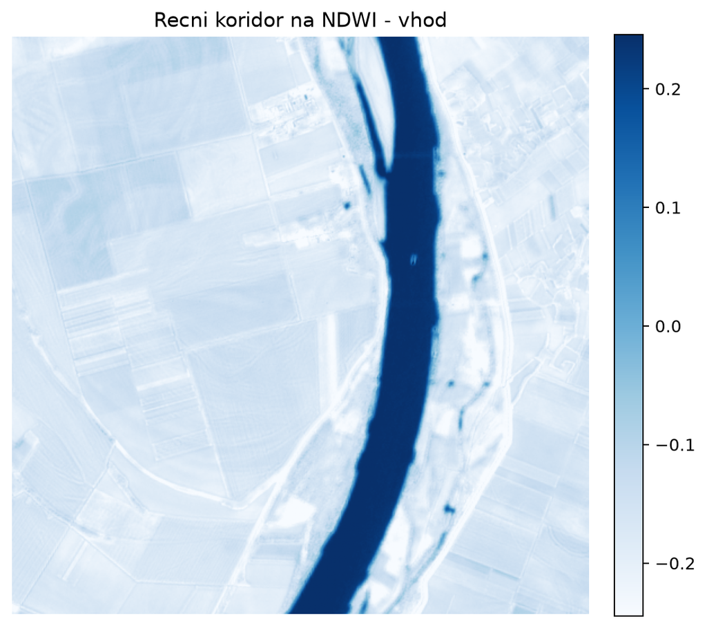

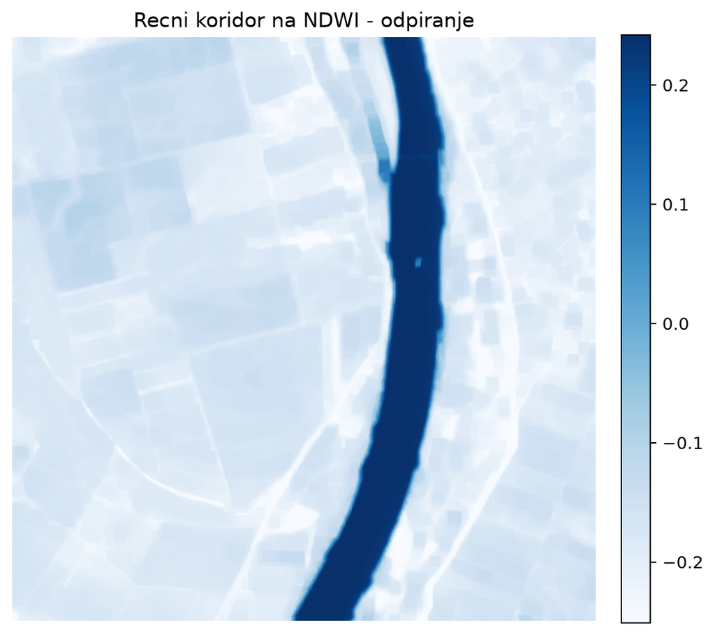

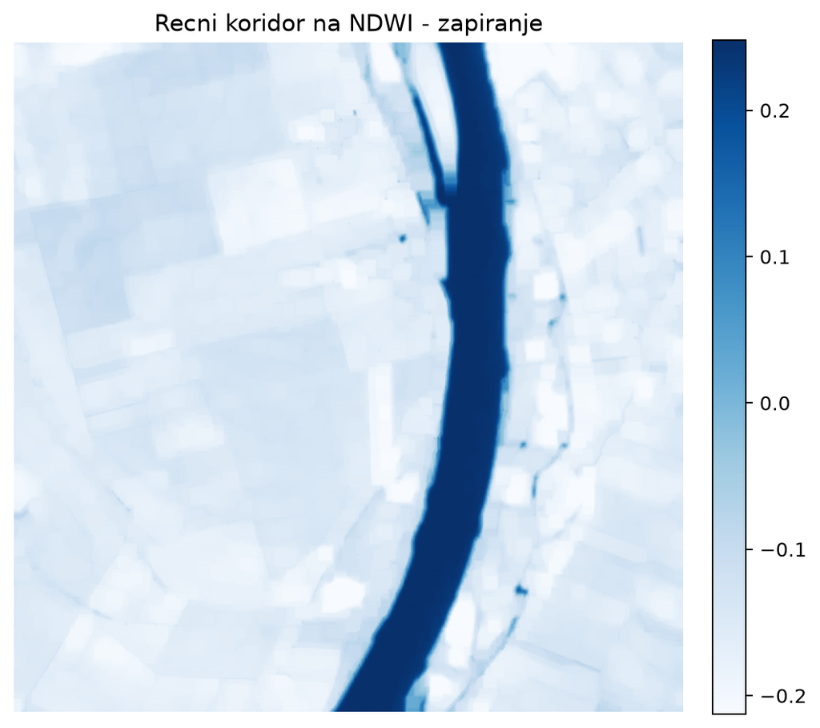

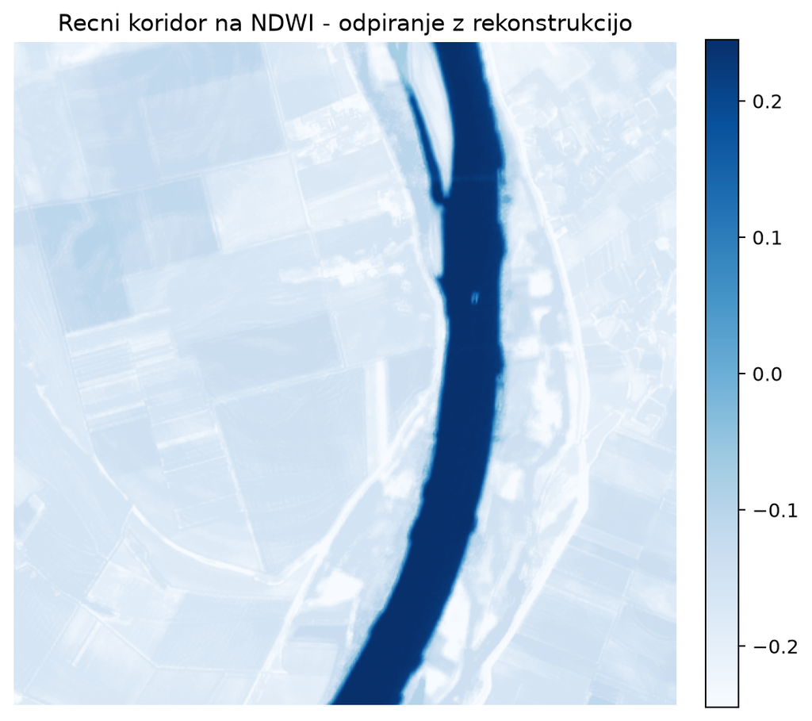

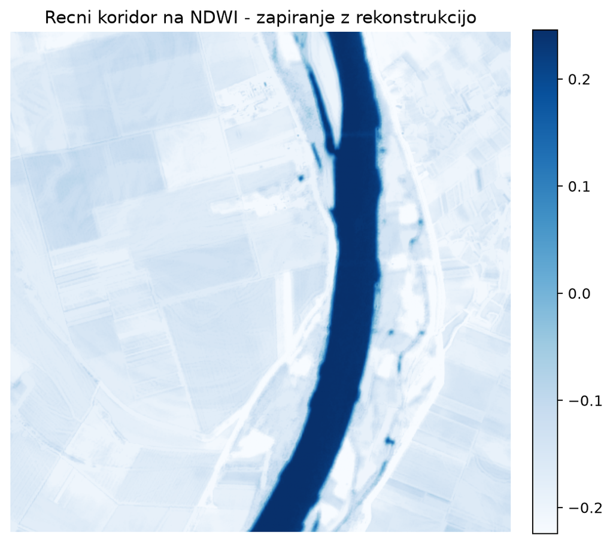

|  | operation | seconds | iterations |
| --- | --- | --- | --- |
| 0 | opening_by_reconstruction | 0.1005 | 149 |
| 1 | closing_by_reconstruction | 0.2177 | 340 |

Poljska mreza na NDVI

- Podrocje: field_mosaic

- Indeks: NDVI

- Koordinate izreza: x=900, y=1000, size=1024

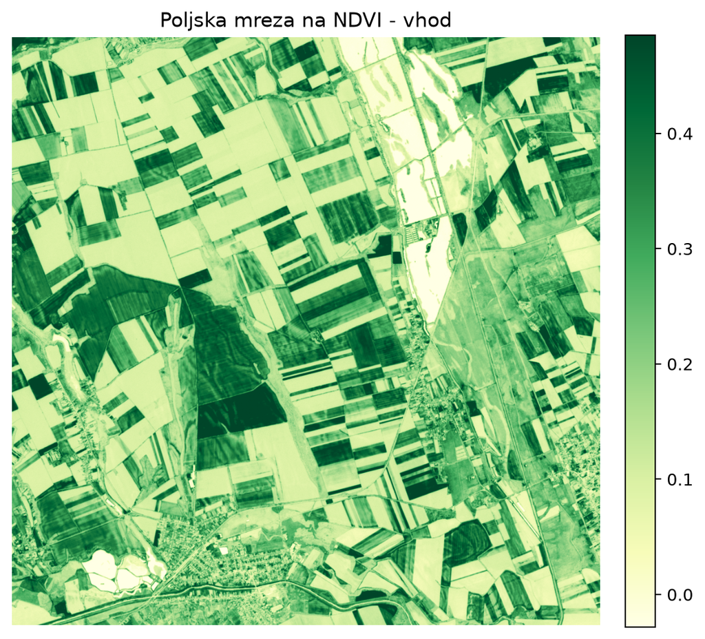

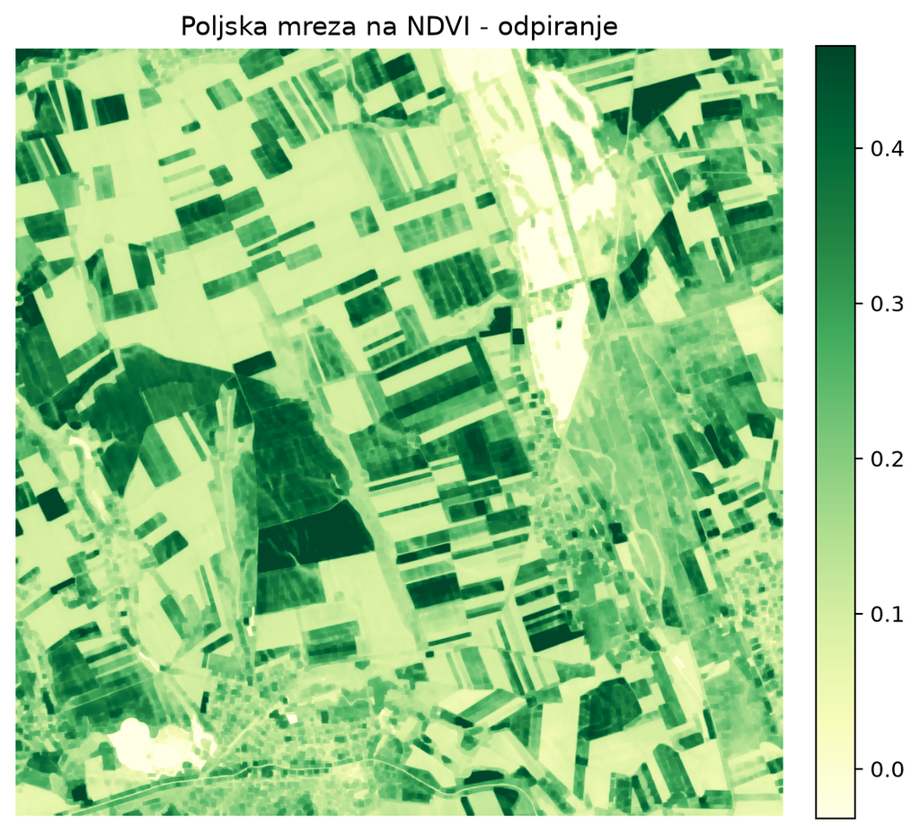

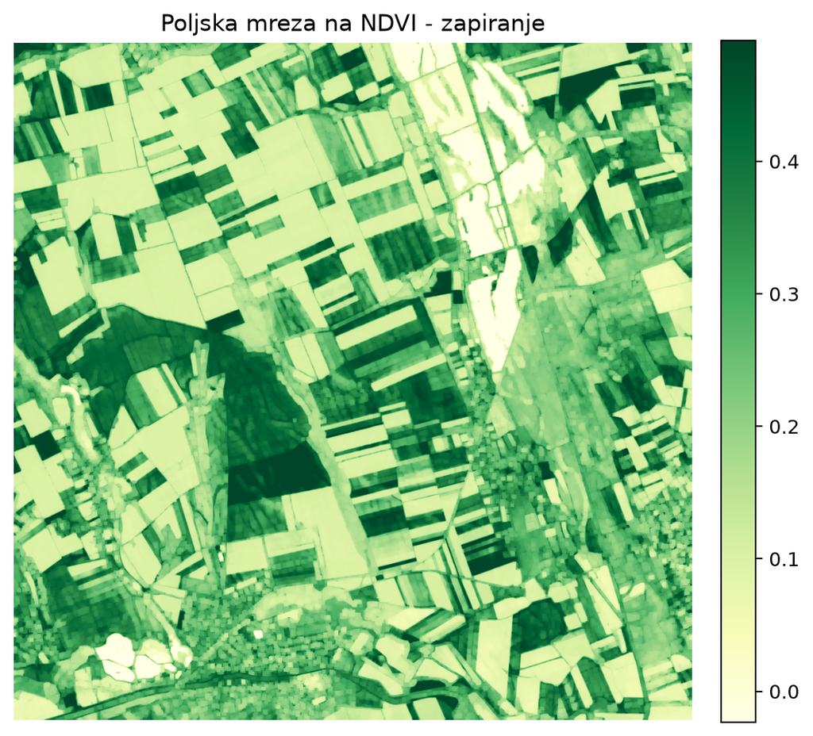

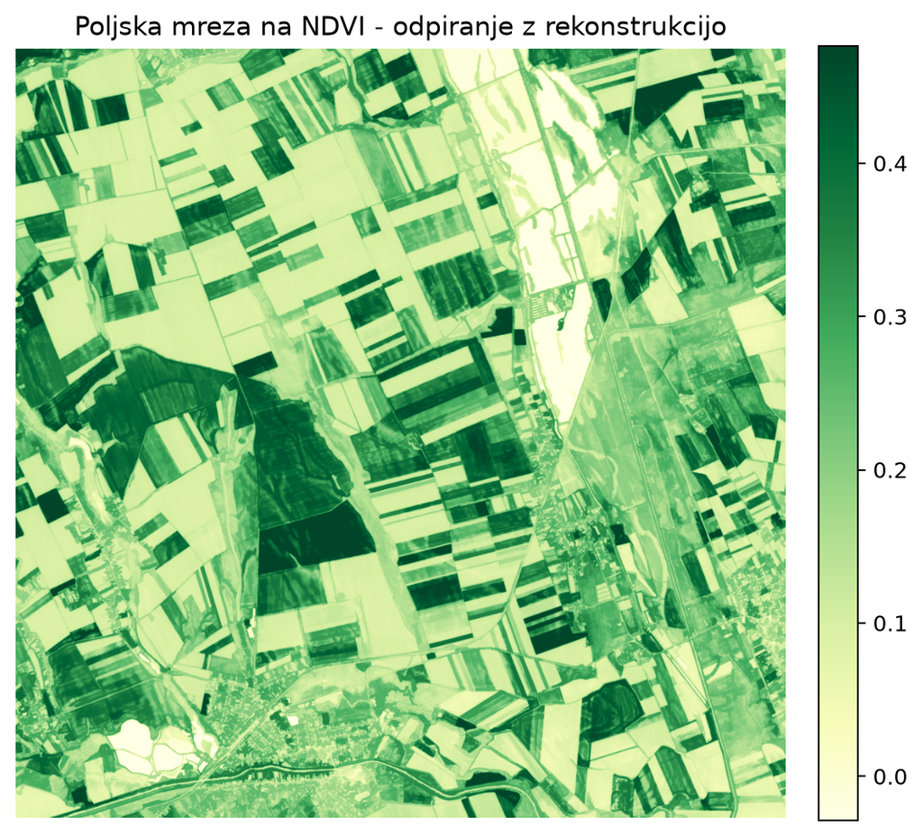

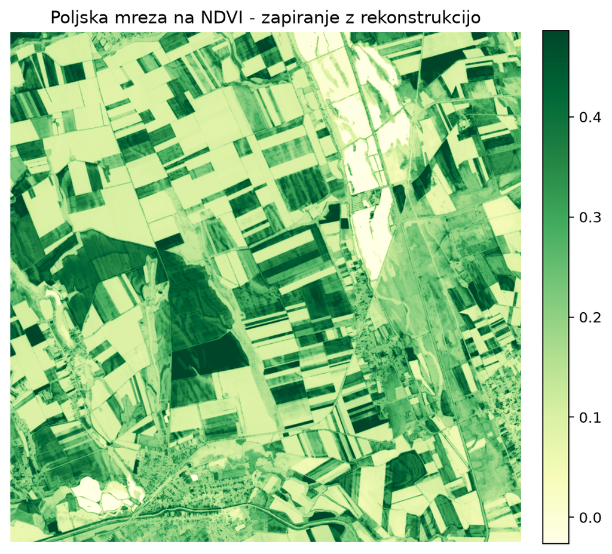

|  | operation | seconds | iterations |
| --- | --- | --- | --- |
| 0 | opening_by_reconstruction | 0.8247 | 288 |
| 1 | closing_by_reconstruction | 0.9236 | 341 |

Pozidano obmocje na NDBI

- Podrocje: builtup_patch

- Indeks: NDBI

- Koordinate izreza: x=9300, y=100, size=1024

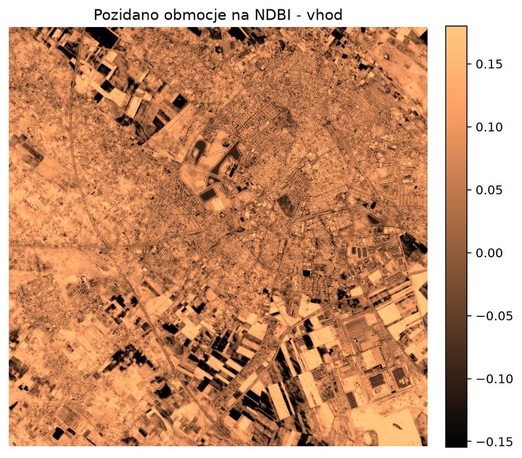

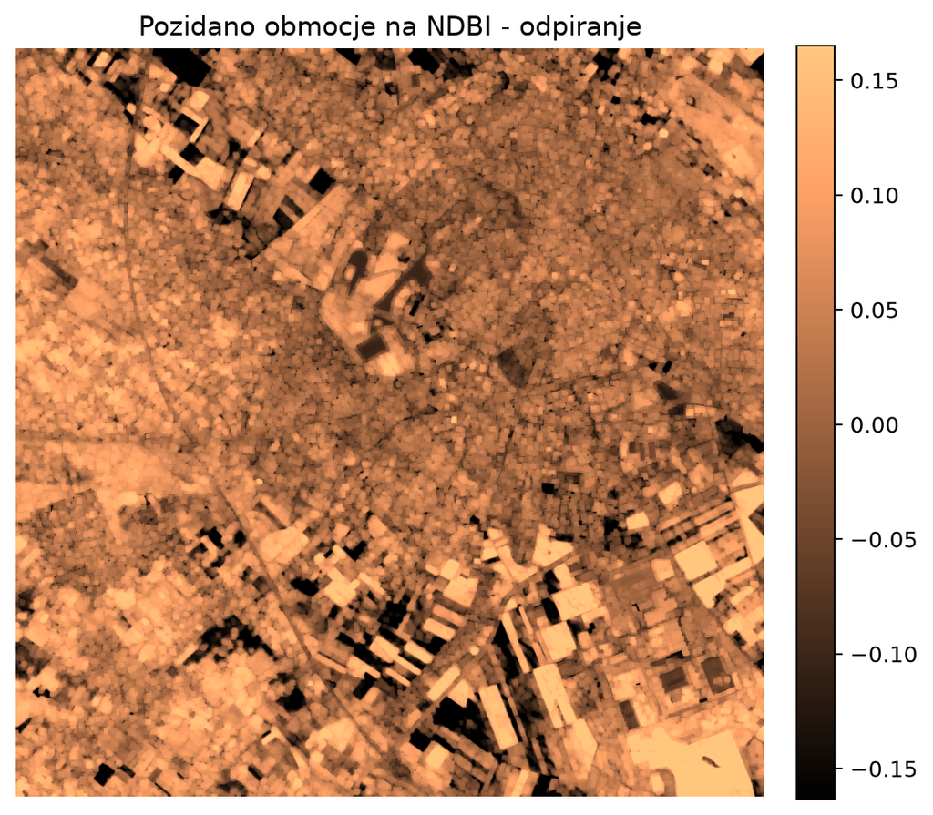

[3 more figures not shown]

|  | operation | seconds | iterations |
| --- | --- | --- | --- |
| 0 | opening_by_reconstruction | 0.3003 | 111 |
| 1 | closing_by_reconstruction | 0.5270 | 197 |

```python
for area_code, result in RESULTS_BY_AREA.items():
    experiment = result['experiment']
    display(Markdown(f"### {experiment.title}"))
    display(Markdown(f"- Podrocje: {experiment.area_code}\n- Indeks: {experiment.index_code.upper()}\n- Koordinate izreza: x={experiment.x}, y={experiment.y}, size={experiment.size}"))
    display(Image(filename=str(result['input_png'])))
    display(Image(filename=str(result['opening_png'])))
    display(Image(filename=str(result['closing_png'])))
    display(Image(filename=str(result['opening_rec_png'])))
    display(Image(filename=str(result['closing_rec_png'])))

    square_metrics = METRICS_DF[(METRICS_DF['area_code'] == area_code) & (METRICS_DF['shape'] == 'square')].copy()
    display(square_metrics[['operation', 'seconds', 'iterations']].round({'seconds': 4}).reset_index(drop=True))
```

## Primerjava filtrov

V bonus delu primerjam vse tri oblike filtrov pri obeh rekonstrukcijskih postopkih. Zanima me predvsem cas izvajanja in stevilo iteracij do konvergence.

```python
COMPARISON_WIDE_DF = METRICS_DF.pivot_table(
    index=['area_code', 'index_code'],
    columns=['shape', 'operation'],
    values=['seconds', 'iterations'],
)
COMPARISON_WIDE_DF.columns = [f'{value}_{shape}_{operation}' for value, shape, operation in COMPARISON_WIDE_DF.columns]
COMPARISON_WIDE_DF = COMPARISON_WIDE_DF.reset_index()
COMPARISON_WIDE_DF.to_csv(OUTPUT_TABLES_DIR / 'reconstruction_metrics_wide.csv', index=False)

summary_lines = []
for operation in ['opening_by_reconstruction', 'closing_by_reconstruction']:
    best_rows = METRICS_DF.loc[METRICS_DF.groupby(['area_code', 'operation'])['seconds'].idxmin()].sort_values(['area_code', 'operation'])
    for row in best_rows[best_rows['operation'] == operation].itertuples(index=False):
        label = 'odpiranju z rekonstrukcijo' if operation == 'opening_by_reconstruction' else 'zapiranju z rekonstrukcijo'
        summary_lines.append(f"- Pri {row.area_code} je bil najhitrejsi filter za {label} {row.shape} ({row.seconds:.4f} s, {row.iterations} iteracij).")

display(COMPARISON_WIDE_DF.round(4))
display(Markdown('### Kratek povzetek\n' + '\n'.join(summary_lines)))
```

|  | area_code | index_code | iterations_cross_closing_by_reconstruction | iterations_cross_opening_by_reconstruction | iterations_disk_closing_by_reconstruction | iterations_disk_opening_by_reconstruction | iterations_square_closing_by_reconstruction | iterations_square_opening_by_reconstruction | seconds_cross_closing_by_reconstruction | seconds_cross_opening_by_reconstruction | seconds_disk_closing_by_reconstruction | seconds_disk_opening_by_reconstruction | seconds_square_closing_by_reconstruction | seconds_square_opening_by_reconstruction |
| --- | --- | --- | --- | --- | --- | --- | --- | --- | --- | --- | --- | --- | --- | --- |
| 0 | builtup_patch | ndbi | 127.0 | 155.0 | 133.0 | 155.0 | 197.0 | 111.0 | 0.1678 | 0.2027 | 0.1744 | 0.2033 | 0.5270 | 0.3003 |
| 1 | field_mosaic | ndvi | 332.0 | 179.0 | 344.0 | 179.0 | 341.0 | 288.0 | 0.4332 | 0.2330 | 0.4501 | 0.2364 | 0.9236 | 0.8247 |
| 2 | river_corridor | ndwi | 234.0 | 171.0 | 425.0 | 203.0 | 340.0 | 149.0 | 0.0745 | 0.0620 | 0.1343 | 0.0674 | 0.2177 | 0.1005 |

Kratek povzetek

- Pri builtup_patch je bil najhitrejsi filter za odpiranju z rekonstrukcijo cross (0.2027 s, 155 iteracij).

- Pri field_mosaic je bil najhitrejsi filter za odpiranju z rekonstrukcijo cross (0.2330 s, 179 iteracij).

- Pri river_corridor je bil najhitrejsi filter za odpiranju z rekonstrukcijo cross (0.0620 s, 171 iteracij).

- Pri builtup_patch je bil najhitrejsi filter za zapiranju z rekonstrukcijo cross (0.1678 s, 127 iteracij).

- Pri field_mosaic je bil najhitrejsi filter za zapiranju z rekonstrukcijo cross (0.4332 s, 332 iteracij).

- Pri river_corridor je bil najhitrejsi filter za zapiranju z rekonstrukcijo cross (0.0745 s, 234 iteracij).

## Zakljucek

Na treh izbranih primerih so prikazani ucinki osnovnih morfoloskih operacij in rekonstrukcije. Razlike med odpiranje, zapiranjem in obema rekonstrukcijskima postopkoma so najbolj vidne pri odstranjevanju manjsih struktur ter pri ohranjanju glavne oblike opazovanega podrocja.